# Optimal Treatment Analysis

## Outcome Variable

**Outcome Variable:** haz

## Predictor Variables

**Intervention Variable:** single

**Adjustment Set:**

- arm
- W_mage
- meducyrs
- feducyrs
- W_mhtcm
- W_mwtkg
- W_mbmi
- delta_W_mage
- delta_meducyrs
- delta_feducyrs
- delta_W_mhtcm
- delta_W_mwtkg
- delta_W_mbmi

## Stratifying Variables

The analysis was stratified on these variable(s):

- agecat
- studyid
- country

## Data Summary

| agecat | studyid | country | single | n_cell | n |
| --- | --- | --- | --- | --- | --- |
| Birth | ki0047075b-MAL-ED | BANGLADESH | 0 | 231 | 231 |
| Birth | ki0047075b-MAL-ED | BANGLADESH | 1 | 0 | 231 |
| Birth | ki0047075b-MAL-ED | BRAZIL | 0 | 57 | 65 |
| Birth | ki0047075b-MAL-ED | BRAZIL | 1 | 8 | 65 |
| Birth | ki0047075b-MAL-ED | INDIA | 0 | 47 | 47 |
| Birth | ki0047075b-MAL-ED | INDIA | 1 | 0 | 47 |
| Birth | ki0047075b-MAL-ED | NEPAL | 0 | 27 | 27 |
| Birth | ki0047075b-MAL-ED | NEPAL | 1 | 0 | 27 |
| Birth | ki0047075b-MAL-ED | PERU | 0 | 209 | 233 |
| Birth | ki0047075b-MAL-ED | PERU | 1 | 24 | 233 |
| Birth | ki0047075b-MAL-ED | SOUTH AFRICA | 0 | 63 | 123 |
| Birth | ki0047075b-MAL-ED | SOUTH AFRICA | 1 | 60 | 123 |
| Birth | ki0047075b-MAL-ED | TANZANIA, UNITED REPUBLIC OF | 0 | 122 | 125 |
| Birth | ki0047075b-MAL-ED | TANZANIA, UNITED REPUBLIC OF | 1 | 3 | 125 |
| Birth | ki1119695-PROBIT | BELARUS | 0 | 13348 | 13890 |
| Birth | ki1119695-PROBIT | BELARUS | 1 | 542 | 13890 |
| Birth | ki1126311-ZVITAMBO | ZIMBABWE | 0 | 12942 | 13817 |
| Birth | ki1126311-ZVITAMBO | ZIMBABWE | 1 | 875 | 13817 |
| Birth | ki1135781-COHORTS | GUATEMALA | 0 | 719 | 767 |
| Birth | ki1135781-COHORTS | GUATEMALA | 1 | 48 | 767 |
| Birth | ki1135781-COHORTS | INDIA | 0 | 4771 | 4778 |
| Birth | ki1135781-COHORTS | INDIA | 1 | 7 | 4778 |
| Birth | ki1135781-COHORTS | PHILIPPINES | 0 | 2936 | 3010 |
| Birth | ki1135781-COHORTS | PHILIPPINES | 1 | 74 | 3010 |
| Birth | kiGH5241-JiVitA-4 | BANGLADESH | 0 | 2814 | 2819 |
| Birth | kiGH5241-JiVitA-4 | BANGLADESH | 1 | 5 | 2819 |
| 6 months | ki0047075b-MAL-ED | BANGLADESH | 0 | 241 | 241 |
| 6 months | ki0047075b-MAL-ED | BANGLADESH | 1 | 0 | 241 |
| 6 months | ki0047075b-MAL-ED | BRAZIL | 0 | 179 | 209 |
| 6 months | ki0047075b-MAL-ED | BRAZIL | 1 | 30 | 209 |

[output cut: 54 more lines]

The following strata were considered:

- agecat: 24 months, studyid: ki0047075b-MAL-ED, country: BANGLADESH
- agecat: 24 months, studyid: ki0047075b-MAL-ED, country: BRAZIL
- agecat: 24 months, studyid: ki0047075b-MAL-ED, country: INDIA
- agecat: 24 months, studyid: ki0047075b-MAL-ED, country: NEPAL
- agecat: 24 months, studyid: ki0047075b-MAL-ED, country: PERU
- agecat: 24 months, studyid: ki0047075b-MAL-ED, country: SOUTH AFRICA
- agecat: 24 months, studyid: ki0047075b-MAL-ED, country: TANZANIA, UNITED REPUBLIC OF
- agecat: 24 months, studyid: ki1066203-TanzaniaChild2, country: TANZANIA, UNITED REPUBLIC OF
- agecat: 24 months, studyid: ki1119695-PROBIT, country: BELARUS
- agecat: 24 months, studyid: ki1126311-ZVITAMBO, country: ZIMBABWE
- agecat: 24 months, studyid: ki1135781-COHORTS, country: GUATEMALA
- agecat: 24 months, studyid: ki1135781-COHORTS, country: INDIA
- agecat: 24 months, studyid: ki1135781-COHORTS, country: PHILIPPINES
- agecat: 24 months, studyid: kiGH5241-JiVitA-4, country: BANGLADESH
- agecat: 6 months, studyid: ki0047075b-MAL-ED, country: BANGLADESH
- agecat: 6 months, studyid: ki0047075b-MAL-ED, country: BRAZIL
- agecat: 6 months, studyid: ki0047075b-MAL-ED, country: INDIA
- agecat: 6 months, studyid: ki0047075b-MAL-ED, country: NEPAL
- agecat: 6 months, studyid: ki0047075b-MAL-ED, country: PERU
- agecat: 6 months, studyid: ki0047075b-MAL-ED, country: SOUTH AFRICA
- agecat: 6 months, studyid: ki0047075b-MAL-ED, country: TANZANIA, UNITED REPUBLIC OF
- agecat: 6 months, studyid: ki1066203-TanzaniaChild2, country: TANZANIA, UNITED REPUBLIC OF
- agecat: 6 months, studyid: ki1112895-Guatemala BSC, country: GUATEMALA
- agecat: 6 months, studyid: ki1119695-PROBIT, country: BELARUS
- agecat: 6 months, studyid: ki1126311-ZVITAMBO, country: ZIMBABWE
- agecat: 6 months, studyid: ki1135781-COHORTS, country: GUATEMALA
- agecat: 6 months, studyid: ki1135781-COHORTS, country: INDIA
- agecat: 6 months, studyid: ki1135781-COHORTS, country: PHILIPPINES
- agecat: 6 months, studyid: kiGH5241-JiVitA-4, country: BANGLADESH
- agecat: Birth, studyid: ki0047075b-MAL-ED, country: BANGLADESH
- agecat: Birth, studyid: ki0047075b-MAL-ED, country: BRAZIL
- agecat: Birth, studyid: ki0047075b-MAL-ED, country: INDIA
- agecat: Birth, studyid: ki0047075b-MAL-ED, country: NEPAL
- agecat: Birth, studyid: ki0047075b-MAL-ED, country: PERU
- agecat: Birth, studyid: ki0047075b-MAL-ED, country: SOUTH AFRICA
- agecat: Birth, studyid: ki0047075b-MAL-ED, country: TANZANIA, UNITED REPUBLIC OF
- agecat: Birth, studyid: ki1119695-PROBIT, country: BELARUS
- agecat: Birth, studyid: ki1126311-ZVITAMBO, country: ZIMBABWE
- agecat: Birth, studyid: ki1135781-COHORTS, country: GUATEMALA
- agecat: Birth, studyid: ki1135781-COHORTS, country: INDIA
- agecat: Birth, studyid: ki1135781-COHORTS, country: PHILIPPINES
- agecat: Birth, studyid: kiGH5241-JiVitA-4, country: BANGLADESH

### Dropped Strata

- agecat: Birth, studyid: ki0047075b-MAL-ED, country: BANGLADESH
- agecat: Birth, studyid: ki0047075b-MAL-ED, country: INDIA
- agecat: Birth, studyid: ki0047075b-MAL-ED, country: NEPAL
- agecat: Birth, studyid: ki0047075b-MAL-ED, country: TANZANIA, UNITED REPUBLIC OF
- agecat: 6 months, studyid: ki0047075b-MAL-ED, country: BANGLADESH
- agecat: 6 months, studyid: ki0047075b-MAL-ED, country: INDIA
- agecat: 6 months, studyid: ki0047075b-MAL-ED, country: NEPAL
- agecat: 24 months, studyid: ki0047075b-MAL-ED, country: BANGLADESH
- agecat: 24 months, studyid: ki0047075b-MAL-ED, country: INDIA
- agecat: 24 months, studyid: ki0047075b-MAL-ED, country: NEPAL
- agecat: 24 months, studyid: ki1066203-TanzaniaChild2, country: TANZANIA, UNITED REPUBLIC OF

## Methods Detail

We’re interested in the causal parameters $E[Y_a]$ for all values of $a \in \mathcal{A}$. These parameters represent the mean outcome if, possibly contrary to fact, we intervened to set all units to have $A=a$. Under the randomization and positivity assumptions, these are identified by the statistical parameters $\psi_a=E_W[E_{Y|A,W}(Y|A=a,W)]$. In addition, we’re interested in the mean of $Y$, $E[Y]$ under no intervention (the observed mean). We will estimate these parameters by using SuperLearner to fit the relevant likelihood factors – $E_{Y|A,W}(Y|A=a,W)$ and $p(A=a|W)$, and then updating our likelihood fit using a joint TMLE.

For unadjusted analyses ($W=\{\}$), initial likelihoods were estimated using Lrnr_glm to estimate the simple $E(Y|A)$ and Lrnr_mean to estimate $p(A)$. For adjusted analyses, a small library containing Lrnr_glmnet, Lrnr_xgboost, and Lrnr_mean was used.

# Results Detail

## Results Plots

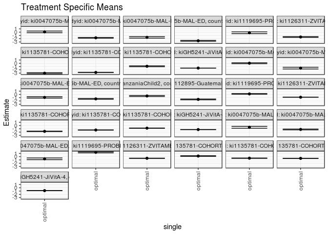

## Results Table

### Parameter: TSM

| agecat | studyid | country | intervention_level | baseline_level | estimate | ci_lower | ci_upper |
| --- | --- | --- | --- | --- | --- | --- | --- |
| Birth | ki0047075b-MAL-ED | BRAZIL | optimal | observed | -0.5384068 | -0.8193905 | -0.2574231 |
| Birth | ki0047075b-MAL-ED | PERU | optimal | observed | -1.1912736 | -1.3227810 | -1.0597662 |
| Birth | ki0047075b-MAL-ED | SOUTH AFRICA | optimal | observed | -0.6540258 | -0.9169226 | -0.3911290 |
| Birth | ki1119695-PROBIT | BELARUS | optimal | observed | 1.3318333 | 1.1669566 | 1.4967100 |
| Birth | ki1126311-ZVITAMBO | ZIMBABWE | optimal | observed | -0.4929769 | -0.5425515 | -0.4434022 |
| Birth | ki1135781-COHORTS | GUATEMALA | optimal | observed | 0.1942440 | 0.1044814 | 0.2840065 |
| Birth | ki1135781-COHORTS | INDIA | optimal | observed | -0.4658126 | -0.5212324 | -0.4103929 |
| Birth | ki1135781-COHORTS | PHILIPPINES | optimal | observed | -0.5164630 | -0.5579678 | -0.4749581 |
| Birth | kiGH5241-JiVitA-4 | BANGLADESH | optimal | observed | -0.8650055 | -0.9020370 | -0.8279741 |
| 6 months | ki0047075b-MAL-ED | BRAZIL | optimal | observed | 0.0203530 | -0.1253576 | 0.1660635 |
| 6 months | ki0047075b-MAL-ED | PERU | optimal | observed | -1.4817940 | -1.7443798 | -1.2192081 |
| 6 months | ki0047075b-MAL-ED | SOUTH AFRICA | optimal | observed | -0.9219500 | -1.1353160 | -0.7085840 |
| 6 months | ki0047075b-MAL-ED | TANZANIA, UNITED REPUBLIC OF | optimal | observed | -1.3621332 | -1.4875067 | -1.2367598 |
| 6 months | ki1066203-TanzaniaChild2 | TANZANIA, UNITED REPUBLIC OF | optimal | observed | -0.4769150 | -0.6400329 | -0.3137972 |
| 6 months | ki1112895-Guatemala BSC | GUATEMALA | optimal | observed | -1.5194429 | -1.6414391 | -1.3974468 |
| 6 months | ki1119695-PROBIT | BELARUS | optimal | observed | 0.1550064 | 0.0548672 | 0.2551456 |
| 6 months | ki1126311-ZVITAMBO | ZIMBABWE | optimal | observed | -0.8612696 | -0.8885070 | -0.8340322 |
| 6 months | ki1135781-COHORTS | GUATEMALA | optimal | observed | -1.7783469 | -1.8505832 | -1.7061107 |
| 6 months | ki1135781-COHORTS | INDIA | optimal | observed | -1.3636063 | -1.4060773 | -1.3211352 |
| 6 months | ki1135781-COHORTS | PHILIPPINES | optimal | observed | -0.7941731 | -0.8289908 | -0.7593554 |
| 6 months | kiGH5241-JiVitA-4 | BANGLADESH | optimal | observed | -1.2258255 | -1.2510433 | -1.2006078 |
| 24 months | ki0047075b-MAL-ED | BRAZIL | optimal | observed | 0.0809253 | -0.1813572 | 0.3432079 |
| 24 months | ki0047075b-MAL-ED | PERU | optimal | observed | -1.7298347 | -1.8565169 | -1.6031524 |
| 24 months | ki0047075b-MAL-ED | SOUTH AFRICA | optimal | observed | -1.5943152 | -1.8297931 | -1.3588373 |
| 24 months | ki0047075b-MAL-ED | TANZANIA, UNITED REPUBLIC OF | optimal | observed | -2.6335000 | -2.7712269 | -2.4957731 |
| 24 months | ki1119695-PROBIT | BELARUS | optimal | observed | -0.1895764 | -0.4662391 | 0.0870864 |
| 24 months | ki1126311-ZVITAMBO | ZIMBABWE | optimal | observed | -1.4789372 | -1.5929947 | -1.3648798 |
| 24 months | ki1135781-COHORTS | GUATEMALA | optimal | observed | -3.0471907 | -3.2246643 | -2.8697171 |
| 24 months | ki1135781-COHORTS | INDIA | optimal | observed | -2.7999472 | -2.8455910 | -2.7543034 |
| 24 months | ki1135781-COHORTS | PHILIPPINES | optimal | observed | -0.9116557 | -1.0461783 | -0.7771332 |
| 24 months | kiGH5241-JiVitA-4 | BANGLADESH | optimal | observed | -1.4645912 | -1.4766314 | -1.4525509 |

### Parameter: E(Y)

| agecat | studyid | country | intervention_level | baseline_level | estimate | ci_lower | ci_upper |
| --- | --- | --- | --- | --- | --- | --- | --- |
| Birth | ki0047075b-MAL-ED | BRAZIL | observed | observed | -0.6760000 | -0.9521457 | -0.3998543 |
| Birth | ki0047075b-MAL-ED | PERU | observed | observed | -0.8827897 | -1.0001058 | -0.7654736 |
| Birth | ki0047075b-MAL-ED | SOUTH AFRICA | observed | observed | -0.6317073 | -0.8249555 | -0.4384591 |
| Birth | ki1119695-PROBIT | BELARUS | observed | observed | 1.3269446 | 1.1683850 | 1.4855041 |
| Birth | ki1126311-ZVITAMBO | ZIMBABWE | observed | observed | -0.5007838 | -0.5213479 | -0.4802197 |
| Birth | ki1135781-COHORTS | GUATEMALA | observed | observed | 0.1511213 | 0.0632481 | 0.2389944 |
| Birth | ki1135781-COHORTS | INDIA | observed | observed | -0.6774424 | -0.7103357 | -0.6445492 |
| Birth | ki1135781-COHORTS | PHILIPPINES | observed | observed | -0.2465548 | -0.2856502 | -0.2074594 |
| Birth | kiGH5241-JiVitA-4 | BANGLADESH | observed | observed | -1.5236006 | -1.5727441 | -1.4744571 |
| 6 months | ki0047075b-MAL-ED | BRAZIL | observed | observed | 0.0475758 | -0.0963508 | 0.1915023 |
| 6 months | ki0047075b-MAL-ED | PERU | observed | observed | -1.3236661 | -1.4316775 | -1.2156546 |
| 6 months | ki0047075b-MAL-ED | SOUTH AFRICA | observed | observed | -1.0633202 | -1.1909180 | -0.9357224 |
| 6 months | ki0047075b-MAL-ED | TANZANIA, UNITED REPUBLIC OF | observed | observed | -1.3687449 | -1.4907629 | -1.2467270 |
| 6 months | ki1066203-TanzaniaChild2 | TANZANIA, UNITED REPUBLIC OF | observed | observed | -0.5457721 | -0.5948454 | -0.4966988 |
| 6 months | ki1112895-Guatemala BSC | GUATEMALA | observed | observed | -1.5624368 | -1.6783540 | -1.4465196 |
| 6 months | ki1119695-PROBIT | BELARUS | observed | observed | 0.1069986 | 0.0122286 | 0.2017686 |
| 6 months | ki1126311-ZVITAMBO | ZIMBABWE | observed | observed | -0.8677917 | -0.8934036 | -0.8421799 |
| 6 months | ki1135781-COHORTS | GUATEMALA | observed | observed | -1.8089474 | -1.8800645 | -1.7378303 |
| 6 months | ki1135781-COHORTS | INDIA | observed | observed | -1.0418789 | -1.0745363 | -1.0092215 |
| 6 months | ki1135781-COHORTS | PHILIPPINES | observed | observed | -1.1414425 | -1.1836656 | -1.0992193 |
| 6 months | kiGH5241-JiVitA-4 | BANGLADESH | observed | observed | -1.3441456 | -1.3814027 | -1.3068885 |
| 24 months | ki0047075b-MAL-ED | BRAZIL | observed | observed | 0.0061144 | -0.1625850 | 0.1748138 |
| 24 months | ki0047075b-MAL-ED | PERU | observed | observed | -1.7524710 | -1.8736426 | -1.6312994 |
| 24 months | ki0047075b-MAL-ED | SOUTH AFRICA | observed | observed | -1.6450595 | -1.7797240 | -1.5103950 |
| 24 months | ki0047075b-MAL-ED | TANZANIA, UNITED REPUBLIC OF | observed | observed | -2.6455607 | -2.7807256 | -2.5103959 |
| 24 months | ki1119695-PROBIT | BELARUS | observed | observed | -0.1314048 | -0.4282725 | 0.1654630 |
| 24 months | ki1126311-ZVITAMBO | ZIMBABWE | observed | observed | -1.6034545 | -1.6603071 | -1.5466018 |
| 24 months | ki1135781-COHORTS | GUATEMALA | observed | observed | -2.9960594 | -3.0622330 | -2.9298858 |
| 24 months | ki1135781-COHORTS | INDIA | observed | observed | -2.2131442 | -2.2522996 | -2.1739887 |
| 24 months | ki1135781-COHORTS | PHILIPPINES | observed | observed | -2.4207616 | -2.4660144 | -2.3755087 |
| 24 months | kiGH5241-JiVitA-4 | BANGLADESH | observed | observed | -1.7811362 | -1.8166519 | -1.7456205 |

### Parameter: PAR

| agecat | studyid | country | intervention_level | baseline_level | estimate | ci_lower | ci_upper |
| --- | --- | --- | --- | --- | --- | --- | --- |
| Birth | ki0047075b-MAL-ED | BRAZIL | optimal | observed | -0.1375932 | -0.2712169 | -0.0039695 |
| Birth | ki0047075b-MAL-ED | PERU | optimal | observed | 0.3084839 | 0.1829492 | 0.4340186 |
| Birth | ki0047075b-MAL-ED | SOUTH AFRICA | optimal | observed | 0.0223185 | -0.1806199 | 0.2252569 |
| Birth | ki1119695-PROBIT | BELARUS | optimal | observed | -0.0048888 | -0.0192563 | 0.0094788 |
| Birth | ki1126311-ZVITAMBO | ZIMBABWE | optimal | observed | -0.0078070 | -0.0528098 | 0.0371959 |
| Birth | ki1135781-COHORTS | GUATEMALA | optimal | observed | -0.0431227 | -0.0697749 | -0.0164705 |
| Birth | ki1135781-COHORTS | INDIA | optimal | observed | -0.2116298 | -0.2748925 | -0.1483671 |
| Birth | ki1135781-COHORTS | PHILIPPINES | optimal | observed | 0.2699082 | 0.2255993 | 0.3142170 |
| Birth | kiGH5241-JiVitA-4 | BANGLADESH | optimal | observed | -0.6585950 | -0.7193573 | -0.5978328 |
| 6 months | ki0047075b-MAL-ED | BRAZIL | optimal | observed | 0.0272228 | -0.0851521 | 0.1395977 |
| 6 months | ki0047075b-MAL-ED | PERU | optimal | observed | 0.1581279 | -0.0704622 | 0.3867180 |
| 6 months | ki0047075b-MAL-ED | SOUTH AFRICA | optimal | observed | -0.1413702 | -0.3247889 | 0.0420485 |
| 6 months | ki0047075b-MAL-ED | TANZANIA, UNITED REPUBLIC OF | optimal | observed | -0.0066117 | -0.0211022 | 0.0078788 |
| 6 months | ki1066203-TanzaniaChild2 | TANZANIA, UNITED REPUBLIC OF | optimal | observed | -0.0688570 | -0.2253463 | 0.0876323 |
| 6 months | ki1112895-Guatemala BSC | GUATEMALA | optimal | observed | -0.0429939 | -0.0824537 | -0.0035341 |
| 6 months | ki1119695-PROBIT | BELARUS | optimal | observed | -0.0480078 | -0.1317989 | 0.0357833 |
| 6 months | ki1126311-ZVITAMBO | ZIMBABWE | optimal | observed | -0.0065221 | -0.0165734 | 0.0035291 |
| 6 months | ki1135781-COHORTS | GUATEMALA | optimal | observed | -0.0306004 | -0.0536746 | -0.0075263 |
| 6 months | ki1135781-COHORTS | INDIA | optimal | observed | 0.3217274 | 0.2727921 | 0.3706627 |
| 6 months | ki1135781-COHORTS | PHILIPPINES | optimal | observed | -0.3472694 | -0.3951507 | -0.2993880 |
| 6 months | kiGH5241-JiVitA-4 | BANGLADESH | optimal | observed | -0.1183200 | -0.1625822 | -0.0740579 |
| 24 months | ki0047075b-MAL-ED | BRAZIL | optimal | observed | -0.0748109 | -0.3132529 | 0.1636311 |
| 24 months | ki0047075b-MAL-ED | PERU | optimal | observed | -0.0226363 | -0.0746171 | 0.0293445 |
| 24 months | ki0047075b-MAL-ED | SOUTH AFRICA | optimal | observed | -0.0507443 | -0.2457491 | 0.1442604 |
| 24 months | ki0047075b-MAL-ED | TANZANIA, UNITED REPUBLIC OF | optimal | observed | -0.0120608 | -0.0317273 | 0.0076057 |
| 24 months | ki1119695-PROBIT | BELARUS | optimal | observed | 0.0581716 | -0.1184911 | 0.2348342 |
| 24 months | ki1126311-ZVITAMBO | ZIMBABWE | optimal | observed | -0.1245173 | -0.2245908 | -0.0244437 |
| 24 months | ki1135781-COHORTS | GUATEMALA | optimal | observed | 0.0511313 | -0.1147522 | 0.2170148 |
| 24 months | ki1135781-COHORTS | INDIA | optimal | observed | 0.5868030 | 0.5325961 | 0.6410100 |
| 24 months | ki1135781-COHORTS | PHILIPPINES | optimal | observed | -1.5091058 | -1.6480983 | -1.3701134 |
| 24 months | kiGH5241-JiVitA-4 | BANGLADESH | optimal | observed | -0.3165450 | -0.3532810 | -0.2798090 |